# Learning Rate Experiments in Neural Networks

**Author:** Ruszed Jy L. Ayad  
**Course:** Deep Learning  
**Purpose:** To study the effect of different learning rates on model convergence and performance.

## Introduction

The **learning rate (η)** is a crucial hyperparameter in training neural networks. It controls how much the model’s weights are updated during optimization. Choosing an appropriate learning rate is essential for stable convergence and good generalization.

The weight update rule in gradient descent is:

[ w_{new} = w_{old} - \eta \nabla L(w) ]

Where:

- ( \eta ) is the learning rate
- ( \nabla L(w) ) is the gradient of the loss function

In this notebook, we conduct a simple experiment to observe how different learning rates affect training behavior.

## Experiment Setup

- **Dataset:** Scikit-learn Digits dataset
- **Model:** Multi-Layer Perceptron (MLP)
- **Optimizer:** Stochastic Gradient Descent (SGD)
- **Learning Rates Tested:**
  - 0.0001 (very small)
  - 0.01 (moderate)
  - 0.1 (large)

All other hyperparameters are kept constant to isolate the effect of the learning rate.

```python
# Import required libraries
import numpy as np
import matplotlib.pyplot as plt
from sklearn.datasets import load_digits
from sklearn.model_selection import train_test_split
from sklearn.neural_network import MLPClassifier
from sklearn.preprocessing import StandardScaler
from sklearn.metrics import accuracy_score
```

```python
# Load and prepare the dataset
digits = load_digits()
X, y = digits.data, digits.target

# Train-test split
X_train, X_test, y_train, y_test = train_test_split(
    X, y, test_size=0.2, random_state=42, stratify=y
)

# Feature scaling
scaler = StandardScaler()
X_train = scaler.fit_transform(X_train)
X_test = scaler.transform(X_test)
```

```python
# Define learning rates to test
learning_rates = [0.0001, 0.01, 0.1]

results = {}
loss_curves = {}
```

```python
# Train models with different learning rates
for lr in learning_rates:
    model = MLPClassifier(
        hidden_layer_sizes=(64,),
        activation='relu',
        solver='sgd',
        learning_rate_init=lr,
        max_iter=50,
        random_state=42,
        verbose=False
    )

    model.fit(X_train, y_train)

    y_pred = model.predict(X_test)
    acc = accuracy_score(y_test, y_pred)

    results[lr] = acc
    loss_curves[lr] = model.loss_curve_

    print(f"Learning Rate: {lr} | Test Accuracy: {acc:.4f}")
```

```
Learning Rate: 0.0001 | Test Accuracy: 0.3917
```

```
Learning Rate: 0.01 | Test Accuracy: 0.9694
Learning Rate: 0.1 | Test Accuracy: 0.9778
```

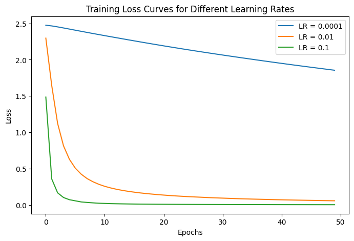

```python
# Plot loss curves for comparison
plt.figure(figsize=(8,5))
for lr, losses in loss_curves.items():
    plt.plot(losses, label=f"LR = {lr}")

plt.xlabel("Epochs")
plt.ylabel("Loss")
plt.title("Training Loss Curves for Different Learning Rates")
plt.legend()
plt.show()
```

## Results and Analysis

### Accuracy Summary:

```python
# Display accuracy results
for lr, acc in results.items():
    print(f"Learning Rate {lr}: Accuracy = {acc:.4f}")
```

```
Learning Rate 0.0001: Accuracy = 0.3917
Learning Rate 0.01: Accuracy = 0.9694
Learning Rate 0.1: Accuracy = 0.9778
```

## Conclusion

In future experiments, techniques such as **learning rate scheduling** or **adaptive optimizers** (e.g., Adam) can be explored to further improve training efficiency.

## References

- Goodfellow, Bengio, Courville. *Deep Learning*. MIT Press
- Scikit-learn Documentation: Neural Networks